# General Linear Regression Quantiles

BH Analytics, LLC

# Objectives

- Calculate a quantile regression
- Use the formula interface for quantile regressions
- Calculate a range of quantiles regression

# General Linear Regression

- We can generalize the ordinary linear model to a more flexible framework
- In regular regression, the predictor variables are on the same scale as the outcome.
- This is often written out in the following form:

$$E(Y) = B_{0} + B_{1}*X_{1} + B_{2}*X_{2} + ... + B_{k}*X_{k} + e$$

- We could also write out this model using the distribution and matrix notation.
- We are assuming the $E(Y)$ follows a normal distribution, with a linear combination of predictors defining the mean, and the variance defined by $sigma$.

$$E(Y) \sim \text{Normal}(\mathbf X \beta,\sigma^2)$$

- A more general framework would be to allow some function to link the predictors to the outcome, and allow different distributions other than the Normal distribution.
- We call this function the ‘link function’.In normal regression it is simply the identity function.
- We can also consider different distributional families for the outcome
- The combination of the link function and the distributional family is the general linear model.

# Motivating Example: Sales data

For this section, we will use some sales data as a motivating example. This is a simulated dataset with both a binary outcome (sale) and a continuous outcome (sale_amount). We will focus on a subset of the data with positive sale amounts. First, we should import the data.

```r
library(data.table)
sale_dt <- fread('Data/Data_Sims/simulated_sales_data/customer_sales1.csv')
summary(sale_dt)
```

```
##   customer_id         sale            sale_amount         region           age            gender            activity         marketing_exposure
##  Min.   :100000   Length:8000        Min.   :   0.0   Min.   : 1.00   Min.   : 21.00   Length:8000        Length:8000        Min.   : 0.000
##  1st Qu.:102496   Class :character   1st Qu.:   0.0   1st Qu.:13.00   1st Qu.: 51.00   Class :character   Class :character   1st Qu.: 3.000
##  Median :104989   Mode  :character   Median : 118.8   Median :26.00   Median : 59.00   Mode  :character   Mode  :character   Median : 4.000
##  Mean   :104987                      Mean   : 249.0   Mean   :25.42   Mean   : 59.13                                         Mean   : 4.791
##  3rd Qu.:107472                      3rd Qu.: 418.9   3rd Qu.:38.00   3rd Qu.: 67.00                                         3rd Qu.: 6.000
##  Max.   :109999                      Max.   :2112.0   Max.   :50.00   Max.   :100.00                                         Max.   :16.000
##        x1              x2               x3               x4               x5         num_accounts    current_customer       income
##  Min.   :14.60   Min.   : 2.012   Min.   : 30.62   Min.   : 0.000   Min.   :0.000   Min.   :0.0000   Length:8000        Min.   : 26.00
##  1st Qu.:43.28   1st Qu.: 8.580   1st Qu.: 86.24   1st Qu.: 8.000   1st Qu.:1.000   1st Qu.:0.0000   Class :character   1st Qu.: 58.00
##  Median :49.85   Median : 9.965   Median : 99.78   Median :10.000   Median :2.000   Median :0.0000   Mode  :character   Median : 65.00
##  Mean   :49.88   Mean   : 9.946   Mean   : 99.79   Mean   : 9.954   Mean   :1.966   Mean   :0.4893                      Mean   : 64.79
##  3rd Qu.:56.76   3rd Qu.:11.294   3rd Qu.:113.33   3rd Qu.:12.000   3rd Qu.:3.000   3rd Qu.:1.0000                      3rd Qu.: 71.00
##  Max.   :89.66   Max.   :17.217   Max.   :168.37   Max.   :22.000   Max.   :9.000   Max.   :4.0000                      Max.   :103.00
```

# Just Sales

We’ll subset down to just the records that have sales (sale_amount > 0)

```r
sales_subset <- sale_dt[sale_amount>0]
```

# Examine the Outcome

- We’ll look at the distribution of the outcome

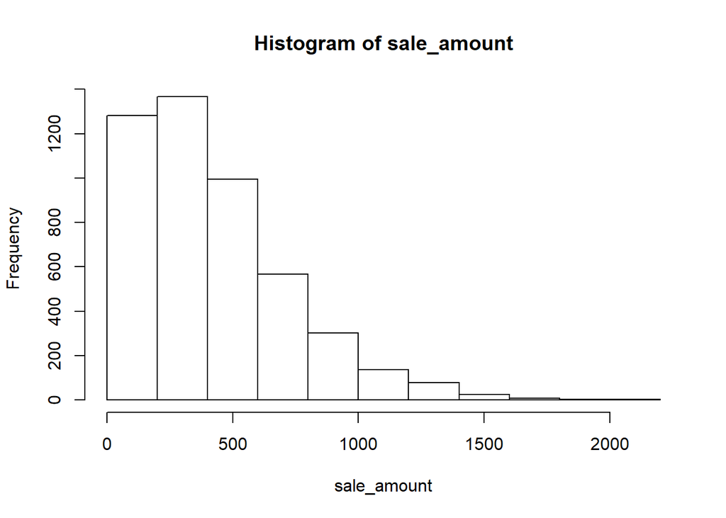

```
## $breaks
##  [1]    0  200  400  600  800 1000 1200 1400 1600 1800 2000 2200
##
## $counts
##  [1] 1283 1366  996  566  302  137   78   24    8    3    2
##
## $density
##  [1] 1.346275e-03 1.433368e-03 1.045121e-03 5.939140e-04 3.168940e-04 1.437566e-04 8.184680e-05 2.518363e-05 8.394544e-06 3.147954e-06 2.098636e-06
##
## $mids
##  [1]  100  300  500  700  900 1100 1300 1500 1700 1900 2100
##
## $xname
## [1] "sale_amount"
##
## $equidist
## [1] TRUE
##
## attr(,"class")
## [1] "histogram"
```

```r
sales_subset[,hist(sale_amount)]
```

```r
sales_subset[,summary(sale_amount)]
```

```
##    Min. 1st Qu.  Median    Mean 3rd Qu.    Max.
##    10.0   185.2   357.9   418.0   582.2  2112.0
```

This looks like a typical strictly positive distribution. Since it is not possible to have a negative sale price, we see a bit of skew, with most of the data focused on lower priced items, and a smaller amount of data in the higher priced items.

# Quantile Regression

```r
sales_subset[,quantile(sale_amount,0.75)]
```

```
##      75%
## 582.1884
```

# Quantile Regression

The interface for quantile regression uses the familiar R formula interface. We can set the `tau` or quantile to fit.

A null model recovers the quantile as calculated.

Note thaat if no quantile is specified the default median is used.

```r
library(quantreg)
fit0 <- rq(sale_amount ~ 1,tau=0.75,data=sales_subset)
summary(fit0)
```

```
##
## Call: rq(formula = sale_amount ~ 1, tau = 0.75, data = sales_subset)
##
## tau: [1] 0.75
##
## Coefficients:
##             Value     Std. Error t value   Pr(>|t|)
## (Intercept) 582.18840   7.62030   76.39962   0.00000
```

# Age by Sale Amount

We can investigate the relationship between age and the 75 percentile of sale amount. If we simply include age in the model as a linear predictor, we are assuming a linear relationship between these variables. Is that appropriate here?

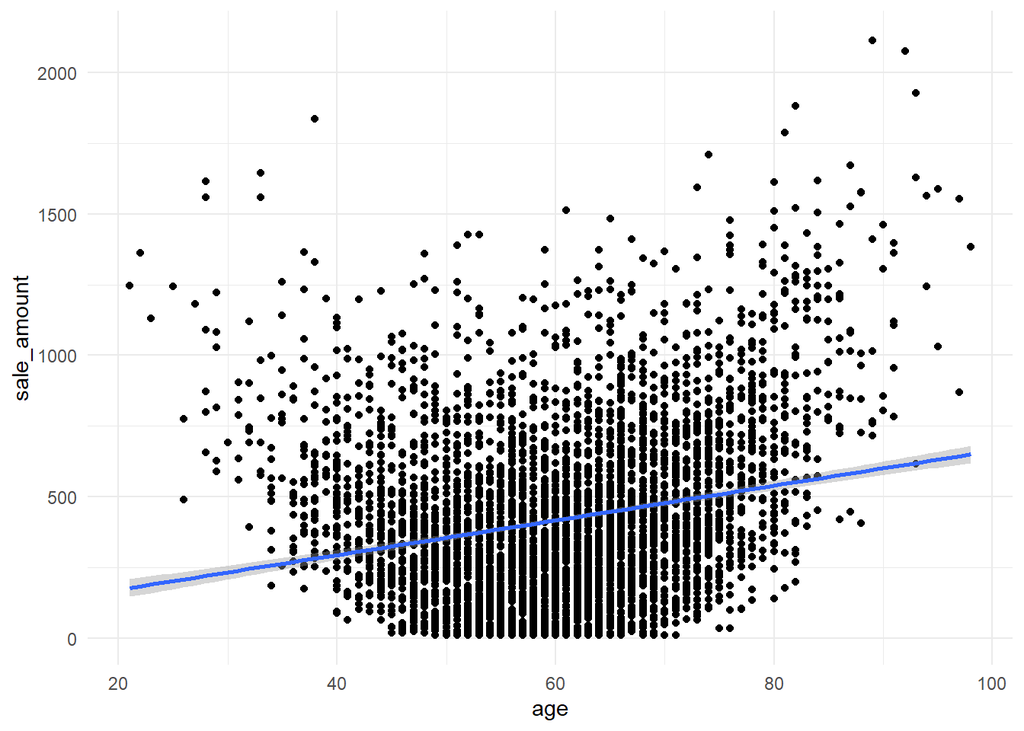

```r
library(ggplot2)
ggplot(sales_subset,
       aes(age,sale_amount)) +
  geom_point() +
  geom_smooth(method='lm') +
  theme_minimal()
```

It looks like there is a non-linear relationship between age and the sale amount. In this case, we may be able to approximate it using a more flexible curve like this:

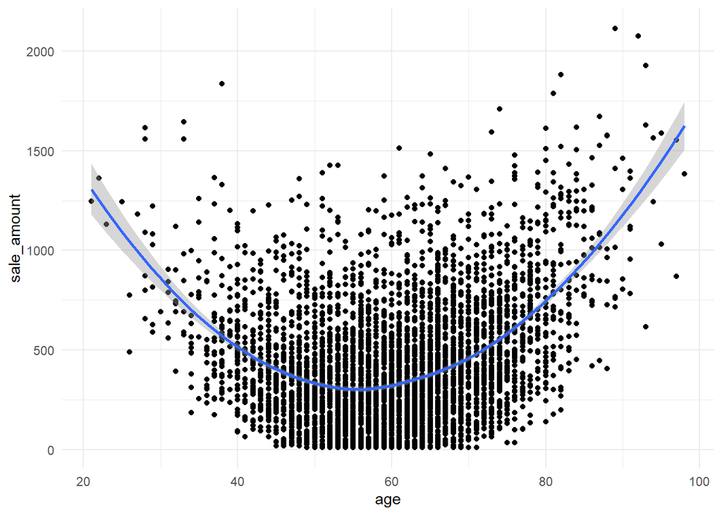

```r
ggplot(sales_subset,aes(age,sale_amount))+geom_point()+geom_smooth(method='loess')+theme_minimal()
```

# Age by Sale Amount with a Polynomial Term

This looks like a good fit to the data. We can fit this in the linear model like so:

```r
fit1 <- rq(sale_amount ~ age + I(age^2),tau=0.75,data=sales_subset)
summary(fit1)
```

```
##
## Call: rq(formula = sale_amount ~ age + I(age^2), tau = 0.75, data = sales_subset)
##
## tau: [1] 0.75
##
## Coefficients:
##             Value      Std. Error t value    Pr(>|t|)
## (Intercept) 3037.68253  108.03724   28.11699    0.00000
## age          -93.96446    3.63797  -25.82885    0.00000
## I(age^2)       0.84992    0.03005   28.28158    0.00000
```

We could also fit this for the median:

```r
fit2 <- rq(sale_amount ~ age + I(age^2),tau=0.5,data=sales_subset)
summary(fit2)
```

```
##
## Call: rq(formula = sale_amount ~ age + I(age^2), tau = 0.5, data = sales_subset)
##
## tau: [1] 0.5
##
## Coefficients:
##             Value      Std. Error t value    Pr(>|t|)
## (Intercept) 2817.03469  104.74917   26.89315    0.00000
## age          -91.18086    3.67534  -24.80881    0.00000
## I(age^2)       0.81254    0.03174   25.59940    0.00000
```

# Non-Linearity: Marketing Exposure

We may also be interested in estimating the effect of marketing exposure on the sale amount. Let’s begin by visualizing the relationship between these variables alone:

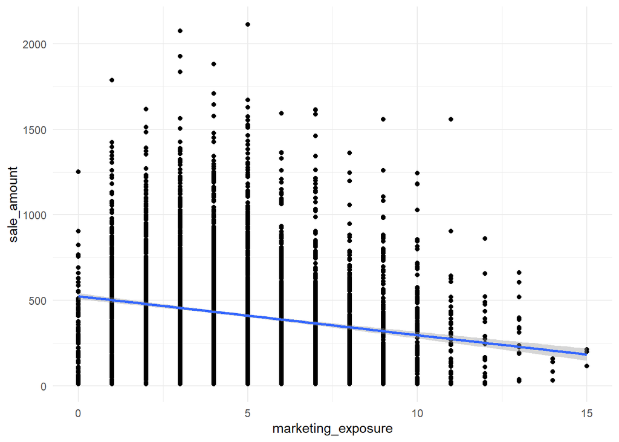

```r
ggplot(sales_subset,aes(marketing_exposure,sale_amount))+geom_point()+geom_smooth(method='lm')+theme_minimal()
```

It looks like there is an overall negative effect of marketing exposure! The more marketing exposure someone recieves, the less likely they are to buy the product?!? We will find this is not the case in the end, but let’s continue with this pairwise investigation for now. We can further examine this relationship by looking at a non-linear fit for this data.

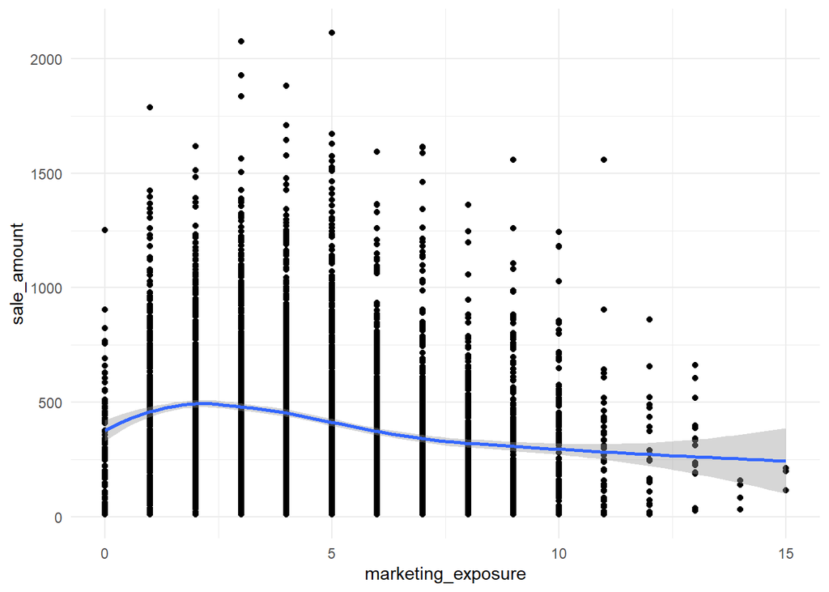

```r
ggplot(sales_subset,aes(marketing_exposure,sale_amount))+geom_point()+geom_smooth(method='loess')+theme_minimal()
```

```r
fit3 <- rq(sale_amount ~ marketing_exposure,tau=0.75,data=sales_subset)
summary(fit3)
```

```
##
## Call: rq(formula = sale_amount ~ marketing_exposure, tau = 0.75, data = sales_subset)
##
## tau: [1] 0.75
##
## Coefficients:
##                    Value     Std. Error t value   Pr(>|t|)
## (Intercept)        721.33972  15.29833   47.15152   0.00000
## marketing_exposure -29.72276   2.46287  -12.06833   0.00000
```

```r
fit4 <- rq(sale_amount ~ splines::bs(marketing_exposure,df=3),tau=0.75,data=sales_subset)
summary(fit4)
```

```
##
## Call: rq(formula = sale_amount ~ splines::bs(marketing_exposure, df = 3),
##     tau = 0.75, data = sales_subset)
##
## tau: [1] 0.75
##
## Coefficients:
##                                          Value      Std. Error t value    Pr(>|t|)
## (Intercept)                               550.39520   34.11556   16.13326    0.00000
## splines::bs(marketing_exposure, df = 3)1  449.10383  103.89310    4.32275    0.00002
## splines::bs(marketing_exposure, df = 3)2 -696.59405   93.10636   -7.48170    0.00000
## splines::bs(marketing_exposure, df = 3)3  195.54548  124.52296    1.57036    0.11640
```

# A Range of Quantiles

We might be interested in a range of quantiles, and how the regression changes amongst these quantiles. Let’s look a more pronounced linear relationship, like the one in the `Advertising` data set.

```r
library(ggplot2)
ads <- fread('Data/Advertising.csv')
summary(ads)
```

```
##      Region             TV             Radio          Newspaper          Sales
##  Min.   :  1.00   Min.   :  0.70   Min.   : 0.000   Min.   :  0.30   Min.   : 1.60
##  1st Qu.: 50.75   1st Qu.: 74.38   1st Qu.: 9.975   1st Qu.: 12.75   1st Qu.:10.38
##  Median :100.50   Median :149.75   Median :22.900   Median : 25.75   Median :12.90
##  Mean   :100.50   Mean   :147.04   Mean   :23.264   Mean   : 30.55   Mean   :14.02
##  3rd Qu.:150.25   3rd Qu.:218.82   3rd Qu.:36.525   3rd Qu.: 45.10   3rd Qu.:17.40
##  Max.   :200.00   Max.   :296.40   Max.   :49.600   Max.   :114.00   Max.   :27.00
```

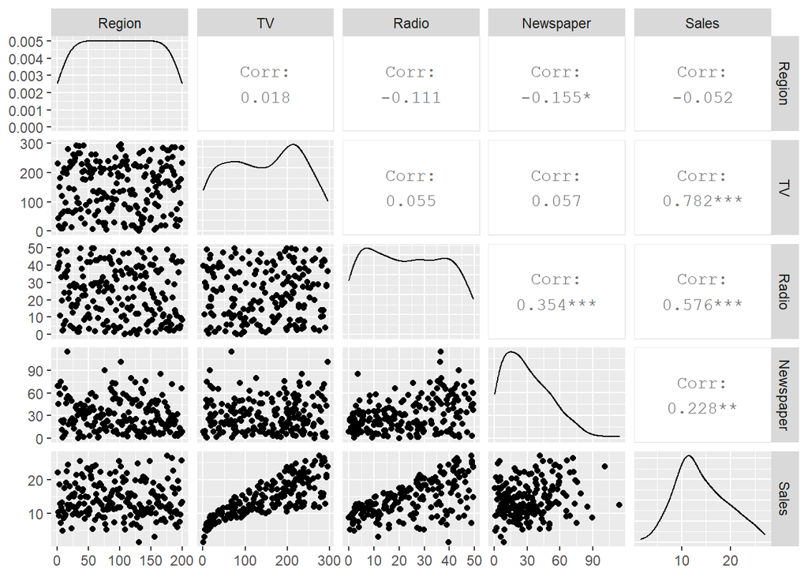

```r
GGally::ggpairs(ads)
```

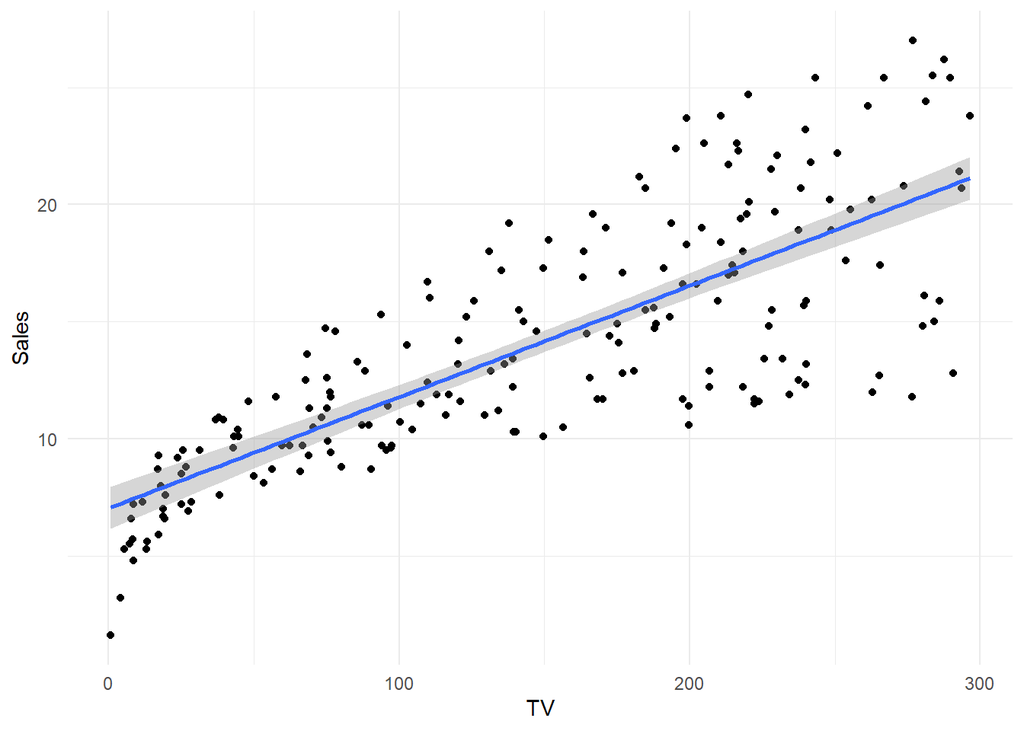

```r
ggplot(ads,aes(TV,Sales))+geom_point()+geom_smooth(method='lm')+theme_minimal()
```

```r
summary(lm(Sales~TV,data=ads))
```

```
##
## Call:
## lm(formula = Sales ~ TV, data = ads)
##
## Residuals:
##     Min      1Q  Median      3Q     Max
## -8.3860 -1.9545 -0.1913  2.0671  7.2124
##
## Coefficients:
##             Estimate Std. Error t value Pr(>|t|)
## (Intercept) 7.032594   0.457843   15.36   <2e-16 ***
## TV          0.047537   0.002691   17.67   <2e-16 ***
## ---
## Signif. codes:  0 '***' 0.001 '**' 0.01 '*' 0.05 '.' 0.1 ' ' 1
##
## Residual standard error: 3.259 on 198 degrees of freedom
## Multiple R-squared:  0.6119, Adjusted R-squared:  0.6099
## F-statistic: 312.1 on 1 and 198 DF,  p-value: < 2.2e-16
```

```r
quantile(ads$Sales,probs = c(1:10/10))
```

```
##   10%   20%   30%   40%   50%   60%   70%   80%   90%  100%
##  7.96  9.70 10.87 11.80 12.90 14.80 16.60 18.92 21.71 27.00
```

# Mean vs Median

- Median data is often considered more robust to outliers
- Consider the difference between the mean fit (the red line)
- To the median fit (the blue dotted line)

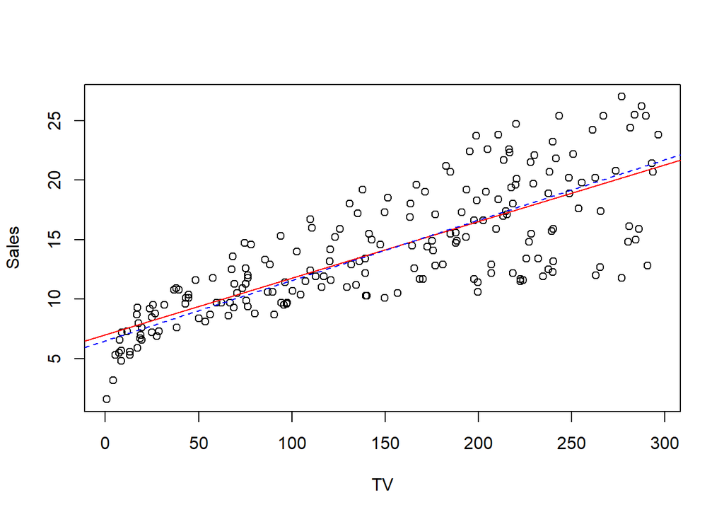

```r
fit_mean <- lm(Sales~TV,data=ads)
fit_median <- rq(Sales~TV,data=ads) #default tau is .5
with(ads,plot(TV,Sales))
abline(fit_mean,col="red")
abline(fit_median,col="blue",lty=2)
```

# Calculating Multiple Quantile Regressions

- We can specify multiple quantiles, and regress on those in one step
- We can use the coefficients in a visualization

```r
taus <- c(1:10/10)
taus
```

```
##  [1] 0.1 0.2 0.3 0.4 0.5 0.6 0.7 0.8 0.9 1.0
```

```r
fitqs <- rq(Sales~TV,taus,data=ads)
fitqs
```

```
## Call:
## rq(formula = Sales ~ TV, tau = taus, data = ads)
##
## Coefficients:
##               tau= 0.1   tau= 0.2  tau= 0.3   tau= 0.4   tau= 0.5   tau= 0.6   tau= 0.7  tau= 0.8   tau= 0.9   tau= 1.0
## (Intercept) 5.44984326 6.35318935 6.1888424 6.06273654 6.52911392 7.03885681 7.55733788 7.9124031 8.32068063 9.28695652
## TV          0.02978056 0.03164239 0.0404463 0.04985444 0.05063291 0.05369515 0.05688282 0.0620155 0.06719023 0.07246377
##
## Degrees of freedom: 200 total; 198 residual
```

```r
# we can call summary on this, but it's a little messy...
summary(fitqs)
```

```
##
## Call: rq(formula = Sales ~ TV, tau = taus, data = ads)
##
## tau: [1] 0.1
##
## Coefficients:
##             coefficients lower bd upper bd
## (Intercept) 5.44984      5.14037  6.18316
## TV          0.02978      0.02547  0.03354
##
## Call: rq(formula = Sales ~ TV, tau = taus, data = ads)
##
## tau: [1] 0.2
##
## Coefficients:
##             coefficients lower bd upper bd
## (Intercept) 6.35319      5.49041  6.53653
## TV          0.03164      0.02995  0.03634
##
## Call: rq(formula = Sales ~ TV, tau = taus, data = ads)
##
## tau: [1] 0.3
##
## Coefficients:
##             coefficients lower bd upper bd
## (Intercept) 6.18884      5.78459  6.77908
## TV          0.04045      0.03325  0.04723
##
## Call: rq(formula = Sales ~ TV, tau = taus, data = ads)
##
## tau: [1] 0.4
##
## Coefficients:
##             coefficients lower bd upper bd
## (Intercept) 6.06274      5.69898  6.81898
## TV          0.04985      0.04174  0.05294
##
## Call: rq(formula = Sales ~ TV, tau = taus, data = ads)
##
## tau: [1] 0.5
```

[output cut: 35 more lines]

```
## tau: [1] 0.9
##
## Coefficients:
##             coefficients lower bd upper bd
## (Intercept) 8.32068      7.83623  9.78866
## TV          0.06719      0.05867  0.07226
##
## Call: rq(formula = Sales ~ TV, tau = taus, data = ads)
##
## tau: [1] 1
##
## Coefficients:
##             coefficients   lower bd       upper bd
## (Intercept)   9.286960e+00 -1.797693e+308  1.797693e+308
## TV            7.246000e-02 -1.797693e+308  1.797693e+308
```

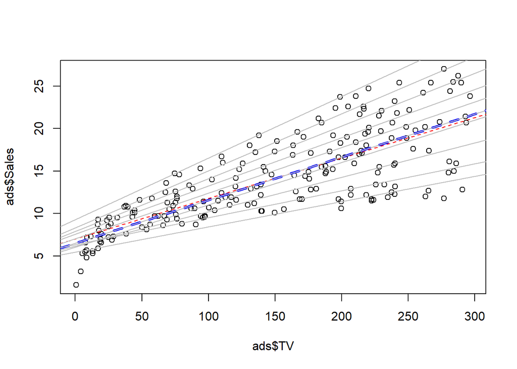

```r
#
plot(ads$TV,ads$Sales)
abline(lm(Sales~TV,data=ads),col="red",lty=2) #mean fit line
abline(fit_median,col="blue",lty=2,lwd=3) #median fit line
for(t in 1:length(taus)){
  abline(coef(fitqs)[,t],col="grey")
}
```

# Plotting Multiple Quantile Regressions

- Calling `plot()` on the mutliple reqressions visualizes and summarizes the values of the coefficients.

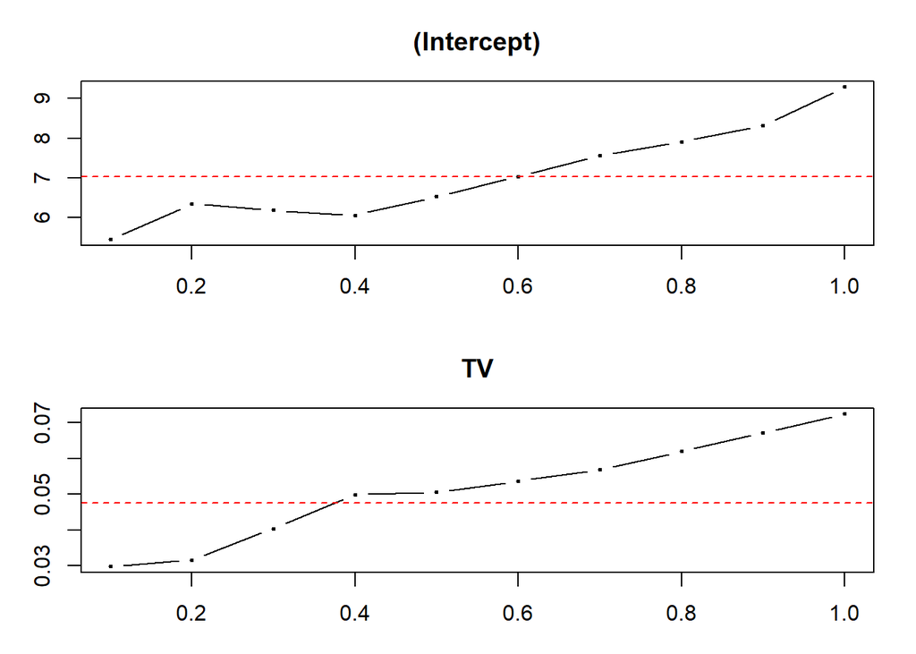

```r
plot(fitqs)
```

# More Multiple Quantile Regressions

- Alternatively, the `rq` command will allow us to search the full quantile space for the data with the `tau = -1` option.
- It turns out there are a finite number of solutions.
- We can plot the solutions.
  - In this example, this demonstrates that what is happening at the lower end of the distribution (the smaller quantiles, tau<0.2) is not the same as beyond this point.
  - This can indicate that the extremes (upper or lower quantiles) behave differently than the center of the distribution
  - Ordinary least squares which estimates the mean response, would not necessarily pick up this level of detail

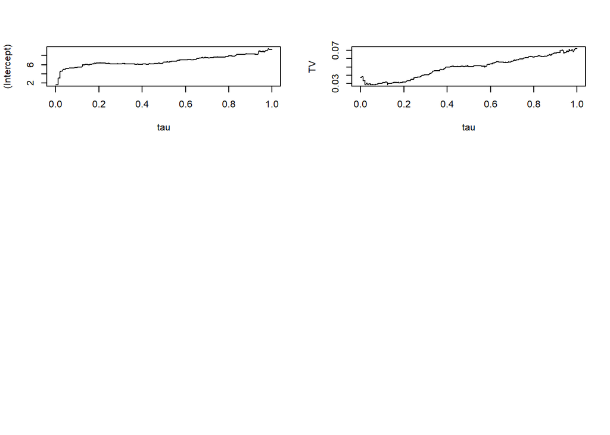

```r
z<- rq(Sales~TV,tau = -1,data=ads)
#z #this produces a lot of output! Uncomment to inspect
#z$sol # this is the "primal solution"
plot(z)
```

# Quantreg Details Methods

- The default calculation method for the quantile regression here is called the “br” method (Barrodale and Roberts algorithm)
- This is recommended for “medium” size problems, but for larger problems, there is a choice of other fitting methods. In the documentation, the next “step up” is the “fn” (Frisch-Newton interior point) method.
- If you are trying to compute quantile regression on larger datasets or larger sets of parameters, consult the documentation. Several alternative computational methods (solvers) are provided.

```r
fit_default <- rq(Sales~TV,tau=0.5,data=ads)
summary(fit_default)
```

```
##
## Call: rq(formula = Sales ~ TV, tau = 0.5, data = ads)
##
## tau: [1] 0.5
##
## Coefficients:
##             coefficients lower bd upper bd
## (Intercept) 6.52911      5.74645  7.16360
## TV          0.05063      0.04704  0.05469
```

```r
#
fit_alt <- rq(Sales~TV,tau=0.5,data=ads, method="fn")
summary(fit_alt)
```

```
##
## Call: rq(formula = Sales ~ TV, tau = 0.5, data = ads, method = "fn")
##
## tau: [1] 0.5
##
## Coefficients:
##             coefficients lower bd upper bd
## (Intercept) 6.52911      5.74645  7.16360
## TV          0.05063      0.04704  0.05469
```

```r
#in this case it won't make much difference
```

# Quantreg Details Standard Errors

- Additionally, there are alternative methods for calculating the standard errors
- The default method is slow for data set sizes over 1000 observations
- We show here the bootstrap alternative, but again check the documents for others and details (there are 7 different methods provided!)

```r
fit_default <- rq(Sales~TV,tau=0.5,data=ads)
summary(fit_default)
```

```
##
## Call: rq(formula = Sales ~ TV, tau = 0.5, data = ads)
##
## tau: [1] 0.5
##
## Coefficients:
##             coefficients lower bd upper bd
## (Intercept) 6.52911      5.74645  7.16360
## TV          0.05063      0.04704  0.05469
```

```r
summary(fit_default,se="boot")
```

```
##
## Call: rq(formula = Sales ~ TV, tau = 0.5, data = ads)
##
## tau: [1] 0.5
##
## Coefficients:
##             Value    Std. Error t value  Pr(>|t|)
## (Intercept)  6.52911  0.44290   14.74172  0.00000
## TV           0.05063  0.00323   15.65382  0.00000
```

# Conclusion

- Quantile regression is easy to implement in R
- Computationally it can be more costly
- Uses the familiar formula interface
- Robust to outliers